# Estadística y Probabilidades I

## Sismos percibidos en Perú desde 1960

**1. ¿Es el estudio de interés para la audiencia?**  
Está información está orientada a las autoridades que se encargan de proyectos comunales, urbanización y organización territorial. Los datos son de mucho interés, ya que saber en qué zonas se puede o no vivir es un criterio muy importante para una OT (Organización Territorial). Asimismo, es de importancia científica, puesto que podemos hallar anomalías o patrones que pueden ser estudiados más a fondo por expertos de la área de investigación correspondiente  
**2. ¿Qué información se desea aportar al final del estudio?**  
Localizar las zonas vulnerables (Latitud longitud) a sismos en el Perú para determinar las zonas habitables y no habitables por personas a causa de su frecuencia y magnitud sísmica para un proyecto de OT. Hallazgo de patrones o anomalías que pueden ser correctamente interpretados por especialistas en el tema y que pueden ser objeto de diferentes hipótesis.  
**3. ¿Es posible llegar a la información que se propone de manera específica y concreta?**  
Si, ya que los datos serán extraídos de la base de datos del Instituto Geofísico Peruano - CENTRO SISMOLOGICO NACIONAL (CENSIS) que se actualiza mensualmente. La información empleada corresponde a la base de datos actualizada hasta el 31 de agosto del año 2021.

### **Objetivos**

#### Objetivos generales

- Determinar susceptibilidad física ante sismos y acumulación de energía sísmica de diferentes regiones del Perú y zonas aledañas de acuerdo a la frecuencia, profundidad y magnitud sísmica
- Identificar irregularidades y tendencias en y entre *Latitud*, *Longitud*, *Magnitud*, *Profundidad*, *Rango de Profundidad*, *Año*, *Mes*, *Día* y *Hora*, variables directamente vinculadas a los sismos en la línea de tiempo desde el año 1960 en el Perú.

#### Objetivos específicos

- Analizar la frecuencia de sismos dadas las variables de la base de datos del IGP
- Destacar figuras de variables que guarden relación entre sí
- Identificar patrones y/o anomalías que puedan presentarse al relacionar variables
- Modelar las variables de manera que puedan adecuarse a una distribución
- Plantear y responder hipótesis realizadas en base a nuestras variables
- Informar acerca de posibles patrones y anomalías presentes al graficar y/o relacionar variables

### **Importancia**

Nuestro proyecto resalta la importancia de identificar las zonas donde suelen ocurrir sismos de diferente magnitud en el Perú, lo cual sería información de suma importancia al realizar, por ejemplo, un proyecto de Ordenamiento Territorial. Nuestras conclusiones nos permitirán identificar las principales zonas vulnerables y encontrar irregularidades, clases o tendencias que, acompañados de un arduo y eficaz proceso de investigación, podrán ser correctamente interpretados o ser objeto de nuevas hipótesis.

### **Factibilidad - Diagrama de Gantt**

A continuación, se muestra como nos hemos organizado y cómo nos organizaremos para llevar a cabo cada entrega del proyecto:

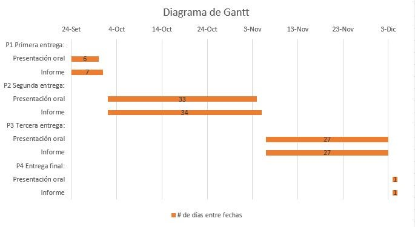

### **Variables de estudio**

[output not shown]

Número de **observaciones**: 22 410

Número de **variables**: 9

**Paquetes** de R empleados: *ggplot2*, *gpubr*, *ggmap*, *readxl*, *tidyverse*, *magrittr*, *kableExtra*, *lubridate*, *anytime*, *skimr*, *summarytools*, *dlookr*, *ggmap*, *Hmisc*, *psych* y *fields*.

### **Limpieza de datos**

Ver *Detalles* para visualizar el proceso de limpieza de datos con R:

A continuación, se lee la base de datos con la función `read_excel()` del paquete *readxl*, se renombran las columnas con `col_names` y se corrigen los tipos de variables con `col_types`:

```r
# Los datos se guardan como un "tibble" en IGP_datos

IGP_datos <- read_excel(
   "IGP_datos_sismicos.xlsx",
    col_names = c("Fecha", "Hora", "Latitud", "Longitud",
                    "Profundidad", "Magnitud")
   )

# Se omite la primera fila

IGP_datos <- IGP_datos[-c(1),]

# Corrección de tipo de variable

IGP_datos$Magnitud %<>% as.double
IGP_datos$Latitud %<>% as.double
IGP_datos$Longitud %<>% as.double
IGP_datos$Profundidad %<>% as.integer
IGP_datos$Fecha %<>% format_dates %<>% anytime
IGP_datos$Hora %<>% hms

#Adición de columna de nivel de profundidad
#(h<60 km), intermedios (61<h<350 km) y profundos (h>351 km).
IGP_datos$Rango_Profundidad <- with(IGP_datos,
                                    factor(
                                      ifelse(Profundidad <= 60, "Superficial",
                                             ifelse(Profundidad <= 350 & Profundidad >= 61, "Intermedio", "Profundo")), levels=c("Superficial", "Intermedio", "Profundo")))
```

No se eliminaron variables ni observaciones, puesto que se determinó que no habían datos faltantes o NA.

Se revisa que no hayan **datos faltantes** con la función `any(is.na())`:

Tabla de valores faltantes (NA/NaN) de cada variable

|  | x |
| --- | --- |
| Fecha | 0 |
| Hora | 0 |
| Latitud | 0 |
| Longitud | 0 |
| Profundidad | 0 |
| Magnitud | 0 |
| Rango_Profundidad | 0 |

Previsualización (uso de `head()`) de las observaciones:  
*La variable *Profundidad* esta en kilómetros

Primeras observaciones de la base de datos del IGP

| Fecha | Hora | Latitud | Longitud | Profundidad | Magnitud | Rango_Profundidad |
| --- | --- | --- | --- | --- | --- | --- |
| 1960-01-13 | 15H 40M 34S | -16.145 | -72.144 | 60 | 7.5 | Superficial |
| 1960-01-15 | 9H 30M 24S | -15.000 | -75.000 | 70 | 7.0 | Intermedio |
| 1960-01-17 | 2H 57M 58S | -14.500 | -74.500 | 150 | 6.4 | Intermedio |
| 1960-01-23 | 3H 37M 32S | -12.500 | -68.500 | 300 | 5.8 | Intermedio |
| 1960-01-30 | 5H 7M 24S | -5.500 | -77.500 | 100 | 5.7 | Intermedio |
| 1960-02-08 | 19H 6M 16S | -8.500 | -74.500 | 136 | 5.3 | Intermedio |

### **Descriptores**

#### **Descriptores numéricos**

Descriptores estadísticos de cada variable

|  | Latitud | Longitud | Magnitud | Profundidad |
| --- | --- | --- | --- | --- |
| Mean | -11.3228670 | -75.7363218 | 4.7469835 | 71.2911647 |
| Std.Dev | 4.4720393 | 3.0812122 | 0.4221457 | 66.3690048 |
| Min | -23.1578000 | -82.8937000 | 3.0000000 | 0.0000000 |
| Q1 | -15.3244000 | -77.7860000 | 4.5000000 | 29.0000000 |
| Median | -11.6102000 | -75.7699500 | 4.7000000 | 49.0000000 |
| Q3 | -7.8518000 | -73.6668000 | 4.9000000 | 106.0000000 |
| Max | -1.4960000 | -68.4390000 | 8.4000000 | 743.0000000 |
| MAD | 5.5298015 | 3.0493375 | 0.2965200 | 40.0302000 |
| IQR | 7.4721750 | 4.1188750 | 0.4000000 | 77.0000000 |
| CV | -0.3949564 | -0.0406834 | 0.0889293 | 0.9309569 |
| Skewness | 0.2364921 | 0.0411735 | 0.8369359 | 3.5414952 |
| Kurtosis | -1.1584053 | -0.6964734 | 4.7453372 | 23.6868351 |

El promedio y la desviación de Latitud y Longitud demuestra que tan dispersos se encuentran los sismos registrados en el globo terráqueo. Qué tan el Este/Oeste o Norte/Sur están. Más adelante se profundizará esta propuesta y realizará un gráfico para representar la concentración de sismos de cierto *Rango de Profundidad* y cierto rango de *Magnitud* de momento.

Se desglosa la variable *Fecha* y *Hora* para tener un análisis más detallado:

Descriptores estadísticos de Año, Mes, Hora y Día

| described_variables | n | na | mean | sd | IQR | skewness | kurtosis | p00 | p25 | p50 | p75 | p100 | CV |
| --- | --- | --- | --- | --- | --- | --- | --- | --- | --- | --- | --- | --- | --- |
| Año | 22410 | 0 | 2002.009505 | 14.577635 | 20 | -0.8545531 | 0.019114 | 1960 | 1994 | 2005 | 2014 | 2021 | 0.0072815 |
| Mes | 22410 | 0 | 6.578269 | 3.447167 | 6 | -0.0138689 | -1.210851 | 1 | 4 | 7 | 10 | 12 | 0.5240234 |
| Hora | 22410 | 0 | 10.884337 | 6.869879 | 12 | 0.1527964 | -1.167887 | 0 | 5 | 10 | 17 | 23 | 0.6311711 |
| Dia | 22410 | 0 | 15.774386 | 8.797434 | 15 | 0.0013705 | -1.195895 | 1 | 8 | 16 | 23 | 31 | 0.5577038 |

Como se puede ver en la tabla superior, no existe variación significante en tanto a frecuencia de sismos según meses, días y horas.

Resumen de variable categórica Rango_Profundidad

| Rango_Profundidad | Frequency | Percent |
| --- | --- | --- |
| Superficial | 13531 | 0.604 |
| Intermedio | 8744 | 0.390 |
| Profundo | 135 | 0.006 |
| Total | 22410 | 1.000 |

#### **Variables aleatorias**

[output not shown]

#### **Descriptores gráficos**

##### **Gráficos de una variable**

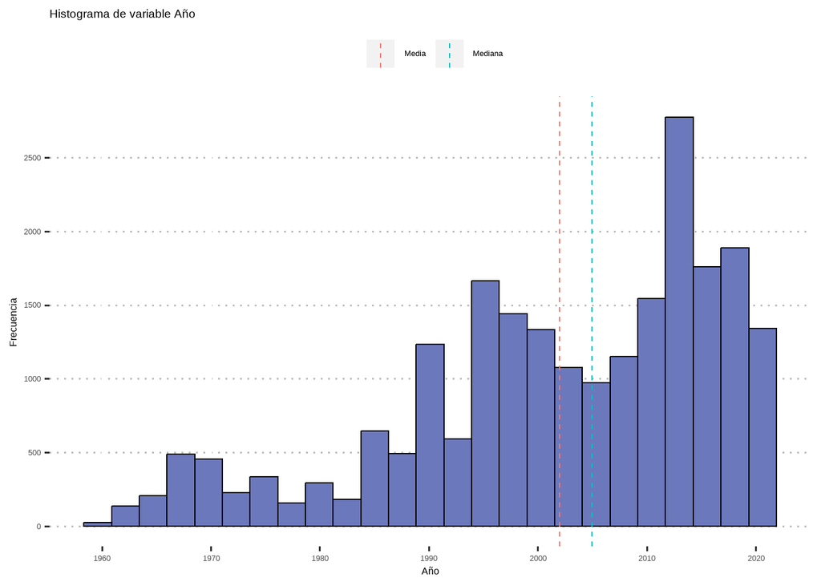

Con la gráfica buscamos saber la cantidad o frecuencia de los sismos en cada año. Se puede apreciar como la frecuencia de sismos ha ido en tendencia de aumento al pasar del tiempo debido a que el Perú se encuentra en el cinturón de fuego del pacifico que en los últimos años ha presentado más colisiones entre las placas. Asimismo, entre los años 2013 y 2014 se ve un aumento grande en la presencia de sismos esto pudo deberse a que en estos años hubo presencia de varios sismos de más de 6 M de magnitud que dejó algo inestable el suelo que permitió la liberación de más energía en menor cantidad pero en mayor proporción. Por otro lado, también es posible que, debido a la gran diferencia de tecnología desde el año 1960 antes no se registraban correctamente todos los sismos. No obstante, esta hipótesis ha sido solventada de manera parcial, puesto que en el 2019 el IGP mencionó que esta tendencia se debía a la diferencia de tecnología, lo cual tuvo como consecuencia más registros en las últimas décadas (Gobierno Peruano, 2019)

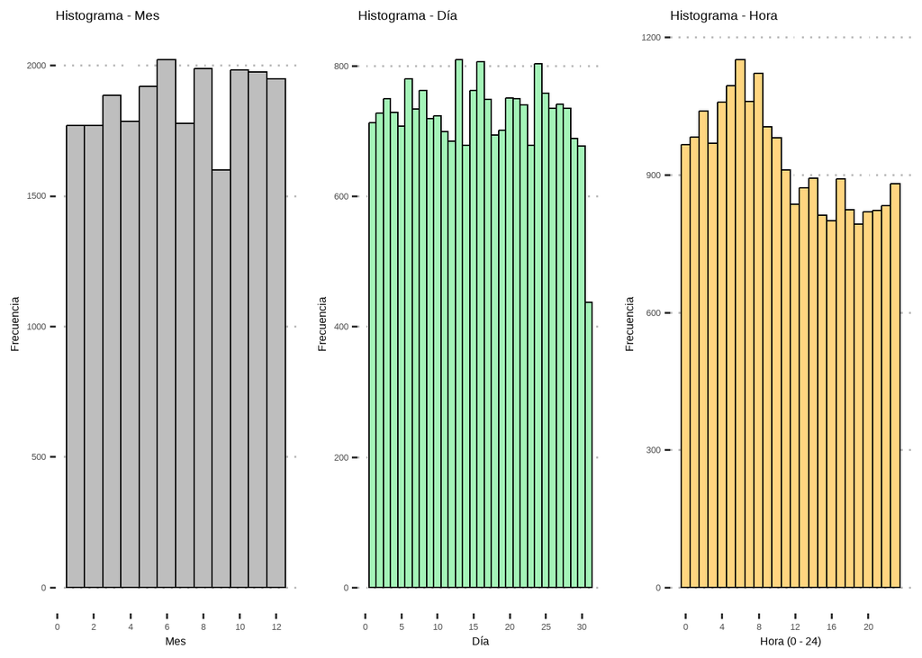

En los tres gráficos de arriba se puede ver como no hay notable diferencia en lo que es frecuencia de sismos por Mes, Día y Hora, en otras palabras, la frecuencia no varía de manera significativa. En el histograma de Día, se puede ver cómo el 31 de cada mes hay menos sismos, ya que no todos los meses tienen un 31.

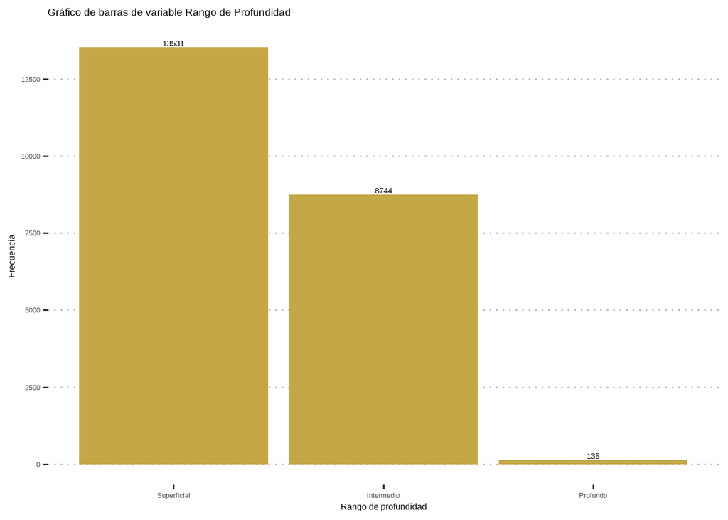

Para esta gráfica se tomaron 3 rangos según la profundidad de cada sismo. Con ello, sabemos si es superficial, intermedio o profundo y la cantidad de los mismos a lo largo del tiempo. Se puede demostrar que la zona más sísmica es la superficial esto debido a que las placas más superficiales son las de mayor movimiento y por tanto mayor liberación de energía.

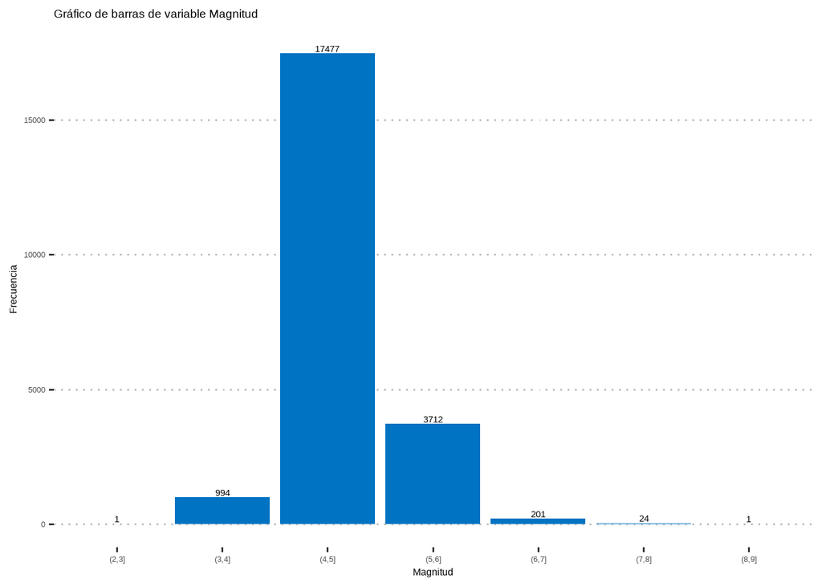

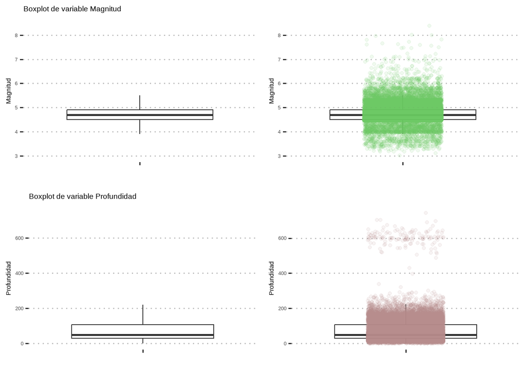

Boxplot de Magnitud - Se puede ver claramente que la gran mayoría de los sismos se dan alrededor de los casi 5 grados de magnitud de momento. Asimismo, hay una clara simetría en los datos centrales. La mediana se encuentra entre 4.5 y 5 grados de magnitud de momento.

Boxplot de Profundidad - En este caso no existe simetría en los datos centrales. Además, se puede evidenciar un grupo de datos extremos que corresponden a los sismos “Profundos”. El grupo de los datos centrales se reparte entre sismos “Superficiales” e “Intermedios”, donde existe una gran concentración de estos. La mitad de los datos inferior se encuentra por debajo de 49 km. Esto indica que por lo menos la mitad de los sismos registrados son “Superficiales”.

##### **Gráficos de dos o más variables**

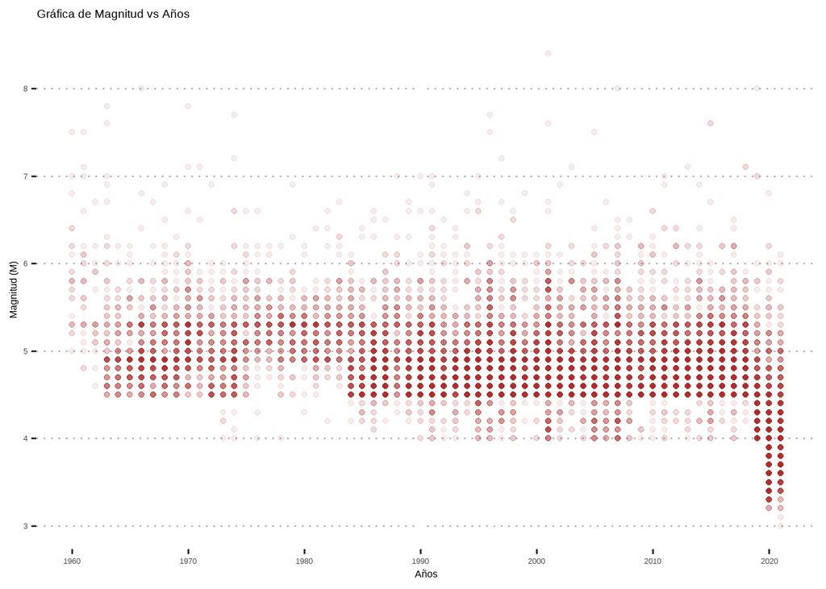

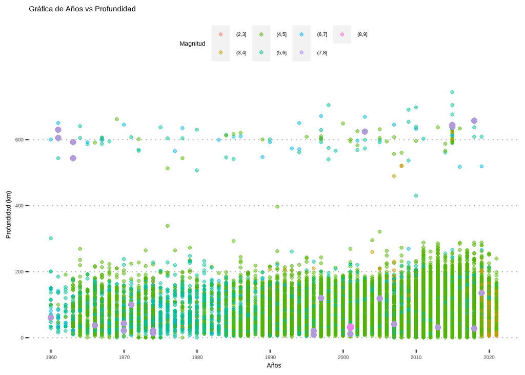

En la gráfica se presenta el patrón de que los sismos a lo largo del tiempo siempre se presentan entre los 5 a los 200 km de profundidad debido a que las placas que están más superficiales al momento de expulsar la energía se logra percibir. En cambio, las placas más profundas al liberar su energía las ondas de choque no llegan con la misma fuerza a la superficie o no llegan a sentirse a excepción de algunos casos que la energía liberada es tanta que si se logra sentir en la superficie. Asimismo, podemos ver como no ha habido tanta presencia de sismos de más de 7 M de magnitud y cabe la posibilidad de presenciar uno muy pronto.

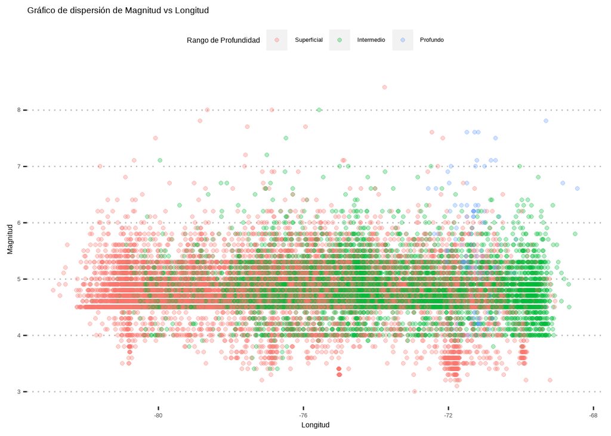

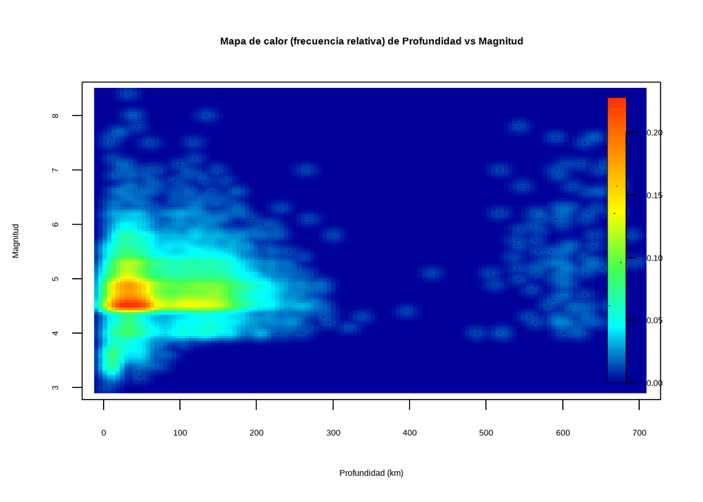

La leyenda (escala) representa la frecuencia relativa de los datos que coinciden en un registro del gráfico

En la gráfica se aprecia como hay una tendencia entre la profundidad y magnitud hasta los 70 km aproximadamente. Además, lo que más resalta de este descriptor sería la concentración de sismos a una profundidad de entre 0 y 70 km, y entre 4.5 y 5 grados de magnitud de momento. Esto se puede evidenciar en la zona roja del gráfico. Esto puede decirnos que a menor profundidad se un mayor movimiento entre placas. Por último, se pueden ver dos grupos de puntos y cómo no hay casi ningún sismo entre los 300 y 500 km de profundidad.

Esta tendencia de los sismos se ve como a lo largo del tiempo se llegan a presentar en un punto a una profundidad que no sobrepasa los 100 KM y a su vez van de los 4 a 5 M en la escala de Richter de magnitud. Con ello podemos intuir que la capa más superficial de la corteza es la más expuesta a los sismos o mejor dicho la que presenta mayor movimiento de sus placas.

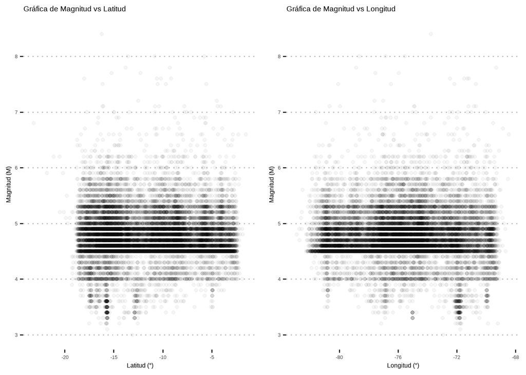

#### **Sismos percibidos en Perú desde el año 1960**

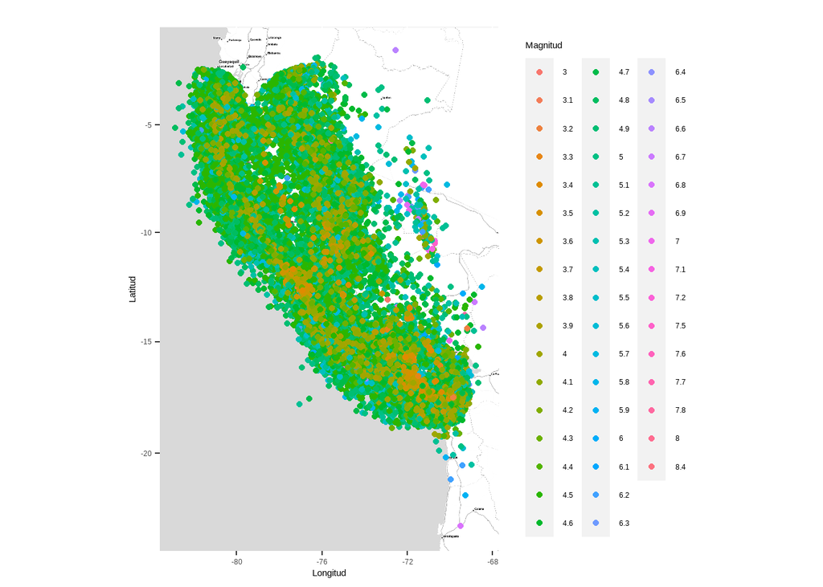

#### *Intervalos de confianza*

En este apartado se calcularon los intervalos de confianza de las variables aleatorias continuas profundidad y magnitud ya definidas anteriormente y la proporción de la variable rango profundidad.  
Dado que el tamaño de nuestra muestra n = 22 410 es mayor que 30 (n > 30), podemos estimar la media **µ** y la desviación típica poblacional **σ** con la desviación típica muestral **S** con un 99% de confianza.

**Parámetros del estudio:**

- Nivel de confianza: 99%
- Significancia (Riesgo): 0.01

Para un nivel de confianza del 99%, el valor de Z es aproximadamente 2.575 como se puede ver en la tabla.

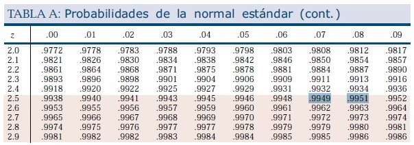

Pero dada las facilidades que nos da R, usaremos la funcion: **qnorm()**

### **Variable magnitud**

- Media muestral (x): 4.7469835
- Desviación estándar mustral: 0.4221457

```r
#PARA LA MEDIA POBLACIONAL
media_magnitud <- 4.7469835
z_magnitud <- qnorm(0.995)
desviacion_magnitud <- 0.4221457
lim_inferior_magnitud <- media_magnitud - z_magnitud*(desviacion_magnitud/sqrt(22410))
lim_superior_magnitud <- media_magnitud + z_magnitud*(desviacion_magnitud/sqrt(22410))

#PARA LA DESVIACION ESTANDAR POBLACIONAL
t_desviacion_magnitud1 <- qchisq(0.995,22409)
t_desviacion_magnitud2 <- qchisq(0.005,22409)
lim_inferior_desviacion_magnitud <- sqrt(22409*(desviacion_magnitud^2)/t_desviacion_magnitud1)
lim_superior_desviacion_magnitud <- sqrt(22409*(desviacion_magnitud^2)/t_desviacion_magnitud2)
```

```r
lim_inferior_magnitud
```

```
## [1] 4.73972
```

```r
lim_superior_magnitud
```

```
## [1] 4.754247
```

```r
lim_inferior_desviacion_magnitud
```

```
## [1] 0.4170671
```

```r
lim_superior_desviacion_magnitud
```

```
## [1] 0.427341
```

| Parámetro descriptor | Límite inferior | Límite superior |
| --- | --- | --- |
| Media poblacional | 4.73972 | 4.754247 |
| D. estándar poblacional | 0.4170671 | 0.427341 |

De la tabla anterior podemos concluir para una población de sismos:  
- La media de la magnitud varía entre **4.73972 - 4.754247**  
- La desviación típica de la magnitud varía entre **0.4170671 - 0.427341**